# Microbiome - differential abundance - BBN mice

Brloajnek-a

2022-07-07

This is based on the tutorial in Orchestrating microbiome analysis (https://microbiome.github.io/OMA/differential-abundance.html). Read in the needed libraries as well as import data in the right format and make it a Tree Summarized experiment.

```r
knitr::opts_chunk$set(warning = FALSE, message = FALSE)
```

```r
library(nlme)
library(tidyverse)
library(compositions)
library(mia)
library(patchwork)
library(tidySummarizedExperiment)
library(qiime2R)
library(ANCOMBC)
library(ALDEx2)
library(Maaslin2)
library(knitr)
```

Load in taxonomy(qza) and count file (tsv) and metadata file (txt). (Hidden code, echo = false)

Prepare data and load into a TreeSummarizedExperiment object.

```r
# Add rownames and remove an additional column
rownames(samples) <- samples$sample.id
samples$sample.id <- NULL

# If e.g. samples do not match between colData and counts table, you must order
# counts based on colData
#if( any( colnames(counts) != rownames(samples) ) ){
#    counts <- counts[ , rownames(samples) ]
#}

# it doesn't match, reordering

rownames(samples)
```

```
##  [1] "AB.1.PT" "AB.2.PT" "AB.3.PT" "AB.4.PT" "AB.5.PT" "AB.6.PT" "AB.1.T"
##  [8] "AB.2.T"  "AB.3.T"  "AB.4.T"  "AB.5.T"  "AB.6.T"  "B.1.PT"  "B.2.PT"
## [15] "B.3.PT"  "B.4.PT"  "B.5.PT"  "B.6.PT"  "B.1.T"   "B.2.T"   "B.4.T"
## [22] "B.5.T"   "B.6.T"
```

```r
colnames(counts)
```

```
##  [1] "AB.1.PT" "AB.1.T"  "AB.2.PT" "AB.2.T"  "AB.3.PT" "AB.3.T"  "AB.4.PT"
##  [8] "AB.4.T"  "AB.5.PT" "AB.5.T"  "AB.6.PT" "AB.6.T"  "B.2.T"   "B.3.PT"
## [15] "B.4.PT"  "B.4.T"   "B.5.PT"  "B.5.T"   "B.6.PT"  "B.6.T"
```

```r
#subset
samples <- samples[rownames(samples) %in% colnames(counts),]
#reorder
samples <- samples[match(colnames(counts), rownames(samples)),]
#now back to line 84 to check again

# And same with rowData and counts...
if( any( rownames(counts) != rownames(tax) ) ){
    counts <- counts[ rownames(tax), ]
}

counts <- as.matrix(counts)

# And it should be added to a SimpleList
assays <-  SimpleList(counts = counts)

# colData and rowData should be in DataFrame format
colData <- DataFrame(samples)
rowData <- DataFrame(tax)

# Create a TreeSE
tse <- TreeSummarizedExperiment(assays = assays,
                                     colData = samples,
                                     rowData = tax)

tse
```

```
## class: TreeSummarizedExperiment
## dim: 2348 20
## metadata(0):
## assays(1): counts
## rownames(2348): d46e2205f0c6ecf67b51f83d111c509c
##   0ebb2cf4a2017aeaefadf9ae5062eb62 ... 69659d7edd60cd37bbdc9e3bb7f77431
##   d85fdf6963c6cd07acb21451a811f84e
## rowData names(7): Kingdom Phylum ... Genus Species
## colnames(20): AB.1.PT AB.1.T ... B.6.PT B.6.T
## colData names(4): sample.type treatment.group subject.id timepoint
## reducedDimNames(0):
## mainExpName: NULL
## altExpNames(0):
## rowLinks: NULL
## rowTree: NULL
## colLinks: NULL
## colTree: NULL
```

```r
head(getTaxonomyLabels(tse))
```

```
## [1] "Family:Enterobacteriaceae" "Family:S24-7"
## [3] "Family:S24-7_1"            "Family:S24-7_2"
## [5] "Species:muciniphila"       "Family:S24-7_3"
```

Subsetting to timepoints PT compare AB vs B groups in the pretreatment.

```r
#how many observations per group?
count(as.data.frame(colData(tse)), treatment.group) %>% kable()
```

| treatment.group | n |
| --- | --- |
| AB | 12 |
| B | 8 |

```r
#timepoint 1 and 6 subsetting
tsePT <- tse[ ,colData(tse)$timepoint == "pretreatment"]
tseT <- tse[ ,colData(tse)$timepoint == "treatment"]


#how many observations per group?
count(as.data.frame(colData(tsePT)), treatment.group) %>% kable()
```

| treatment.group | n |
| --- | --- |
| AB | 6 |
| B | 4 |

```r
count(as.data.frame(colData(tseT)), treatment.group) %>% kable()
```

| treatment.group | n |
| --- | --- |
| AB | 6 |
| B | 4 |

```r
# set a seed because some tools can randomly vary and then produce
# different results:
set.seed(1)

#Prevalence filtering  - removing any ASVs found in fewer than 10% of samples
tse <- subsetByPrevalentTaxa(tse, detection = 0, prevalence = 0.1)
tsePT <- subsetByPrevalentTaxa(tsePT, detection = 0, prevalence = 0.1)
tseT <- subsetByPrevalentTaxa(tseT, detection = 0, prevalence = 0.1)

#agglomerate by rank for which you want to do differential abundance testing
tse_genus <- agglomerateByRank(tse, "Genus")
tsePT_genus <- agglomerateByRank(tsePT, "Genus")
tseT_genus <- agglomerateByRank(tseT, "Genus")
```

Now performing differential aboundance analysis. I will use three methods ALDeX2, Ancom-BC and MaaSlin2 for the comparison (because different methods often produce different results) and compare them. I will use default options for all methods.

ALDEx2

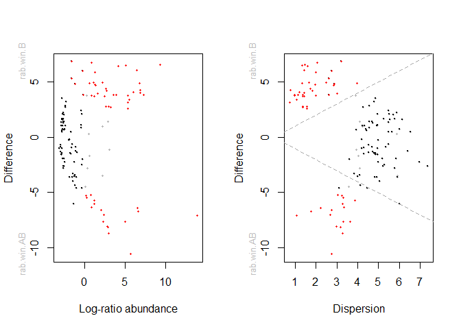

```r
# Pretreatment

x <- aldex.clr(
  reads = assay(tsePT_genus),
  conds = colData(tsePT_genus)$treatment.group,
  # 128 recommened for ttest, 1000 for rigorous effect size calculation
  mc.samples = 128,
  denom = "all",
  verbose = FALSE
)
# calculates expected values of the Welch's t-test and Wilcoxon rank test on
# the data returned by aldex.clr
x_tt <- aldex.ttest(
  x,
  paired.test = FALSE,
  verbose = FALSE)
# determines the median clr abundance of the feature in all samples and in
# groups, the median difference between the two groups, the median variation
# within each group and the effect size, which is the median of the ratio
# of the between group difference and the larger of the variance within groups
x_effect <- aldex.effect(x, CI = TRUE, verbose = FALSE)
# combine all outputs
aldex_outPT <- data.frame(x_tt, x_effect)

#creating an MA plot
par(mfrow = c(1, 2))
aldex.plot(
    aldex_outPT,
    type = "MA",
    test = "welch",
    xlab = "Log-ratio abundance",
    ylab = "Difference",
    cutoff = 0.05
  )
aldex.plot(
    aldex_outPT,
    type = "MW",
    test = "welch",
    xlab = "Dispersion",
    ylab = "Difference",
    cutoff = 0.05
  )
```

```r
rownames_to_column(aldex_outPT, "genus") %>%
  filter(wi.eBH <= 0.05)  %>% # here we chose the wilcoxon output rather than tt
  dplyr::select(genus, we.eBH, wi.eBH, effect, overlap) %>%
  kable()
```

| genus | we.eBH | wi.eBH | effect | overlap |
| --- | --- | --- | --- | --- |
| Family.Enterobacteriaceae | 0.0006197 | 0.0249766 | -6.176953 | 0.0002741 |
| Family.S24.7 | 0.0062937 | 0.0249766 | 4.121899 | 0.0002741 |
| Genus.Akkermansia | 0.0112804 | 0.0249766 | 3.871248 | 0.0002741 |
| Genus.Prevotella | 0.0006495 | 0.0249766 | 5.001740 | 0.0002741 |
| Genus.Lactobacillus | 0.0366439 | 0.0249766 | 2.579157 | 0.0039300 |
| Family.Rikenellaceae | 0.0199369 | 0.0249766 | 3.423476 | 0.0002741 |
| Genus.Odoribacter | 0.0116491 | 0.0249766 | 4.045540 | 0.0002741 |
| Genus.Zoogloea | 0.0418040 | 0.0249766 | -2.808687 | 0.0002741 |
| Genus.Sutterella | 0.0477966 | 0.0270358 | 2.132304 | 0.0117321 |
| Order.Clostridiales | 0.0193601 | 0.0249766 | 3.189255 | 0.0002741 |
| Family.Lachnospiraceae | 0.0156855 | 0.0249766 | 4.572297 | 0.0002741 |
| Genus.Arcobacter | 0.0186769 | 0.0249766 | -3.883076 | 0.0002741 |
| Genus.Allobaculum | 0.0962752 | 0.0277021 | 1.607109 | 0.0078325 |
| Genus.Acinetobacter | 0.0302113 | 0.0249766 | -4.231072 | 0.0002741 |
| Order.RF39 | 0.0143245 | 0.0249766 | 2.567430 | 0.0002741 |
| Genus.Oscillospira | 0.0140235 | 0.0249766 | 3.717742 | 0.0002741 |
| Order.YS2 | 0.0290716 | 0.0249766 | 2.814501 | 0.0002741 |
| Genus..Ruminococcus. | 0.0095406 | 0.0249766 | 3.194899 | 0.0002741 |
| Family.Comamonadaceae | 0.0708557 | 0.0249766 | -2.020040 | 0.0002741 |
| Family.F16 | 0.0091894 | 0.0249766 | 3.131707 | 0.0002741 |
| Genus.Desulfovibrio | 0.0669765 | 0.0289201 | 2.037878 | 0.0116864 |
| Genus.Ruminococcus | 0.0026039 | 0.0249766 | 4.166188 | 0.0002741 |
| Genus.AF12 | 0.0095812 | 0.0249766 | 3.125211 | 0.0002741 |
| Genus.Acidaminobacter | 0.0256700 | 0.0249766 | -2.687957 | 0.0002741 |
| Genus.Rheinheimera | 0.0303283 | 0.0251362 | -2.537228 | 0.0002741 |
| Genus.Dorea | 0.0245747 | 0.0251530 | 2.293771 | 0.0002741 |
| Family.Ruminococcaceae | 0.0142419 | 0.0249766 | 3.660262 | 0.0002741 |
| Genus.Coprococcus | 0.0272958 | 0.0249766 | 2.775120 | 0.0002741 |
| Genus.Dehalobacterium | 0.0436784 | 0.0286052 | 1.445654 | 0.0117321 |
| Genus.Anaeroplasma | 0.0204953 | 0.0249766 | 2.248125 | 0.0002741 |
| Genus.Vogesella | 0.0504855 | 0.0249766 | -2.552704 | 0.0039300 |
| Genus.Anaerostipes | 0.0152017 | 0.0268648 | 2.141600 | 0.0039454 |
| Genus.Corynebacterium | 0.0508964 | 0.0330346 | 1.989366 | 0.0194632 |
| Genus.Roseburia | 0.0322021 | 0.0263283 | 1.671075 | 0.0002741 |
| Genus.Fusibacter | 0.0384136 | 0.0259191 | -2.287386 | 0.0078020 |
| Genus.Adlercreutzia | 0.0525280 | 0.0288682 | 2.115922 | 0.0233529 |
| Genus.Hydrogenophaga | 0.0496018 | 0.0249766 | -2.434559 | 0.0002741 |
| Family..Mogibacteriaceae. | 0.0265735 | 0.0251346 | 1.933461 | 0.0002741 |
| Genus.Butyricicoccus | 0.0274105 | 0.0257540 | 1.846518 | 0.0002741 |
| Genus.Flavobacterium | 0.0367232 | 0.0249766 | -2.758780 | 0.0002741 |
| Genus.Clostridium.1 | 0.0169176 | 0.0251488 | 2.688709 | 0.0002741 |
| Genus.Wautersiella | 0.0546817 | 0.0300196 | -1.884014 | 0.0117321 |
| Genus.Cloacibacterium | 0.0719800 | 0.0378811 | -1.754962 | 0.0156350 |
| Genus.Brevundimonas | 0.0591769 | 0.0264236 | -1.829593 | 0.0078020 |
| Genus.Rikenella | 0.0164191 | 0.0249766 | 2.004680 | 0.0002741 |
| Genus.Candidatus.Arthromitus | 0.0491721 | 0.0328338 | 1.461142 | 0.0155742 |
| Genus.Chryseobacterium | 0.0903257 | 0.0403631 | -1.568264 | 0.0233529 |
| Family.Peptococcaceae | 0.0266974 | 0.0312853 | 1.982548 | 0.0117321 |
| Family.Christensenellaceae | 0.0330846 | 0.0338196 | 1.659012 | 0.0117321 |

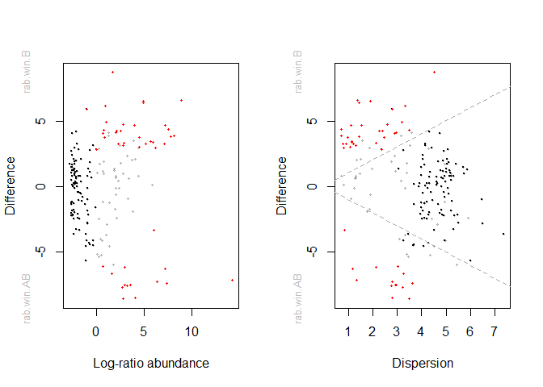

```r
# Treatment

x <- aldex.clr(
  reads = assay(tseT_genus),
  conds = colData(tseT_genus)$treatment.group,
  # 128 recommened for ttest, 1000 for rigorous effect size calculation
  mc.samples = 128,
  denom = "all",
  verbose = FALSE
)
# calculates expected values of the Welch's t-test and Wilcoxon rank test on
# the data returned by aldex.clr
x_tt <- aldex.ttest(
  x,
  paired.test = FALSE,
  verbose = FALSE)
# determines the median clr abundance of the feature in all samples and in
# groups, the median difference between the two groups, the median variation
# within each group and the effect size, which is the median of the ratio
# of the between group difference and the larger of the variance within groups
x_effect <- aldex.effect(x, CI = TRUE, verbose = FALSE)
# combine all outputs
aldex_outT <- data.frame(x_tt, x_effect)

#creating an MA plot
par(mfrow = c(1, 2))
aldex.plot(
    aldex_outT,
    type = "MA",
    test = "welch",
    xlab = "Log-ratio abundance",
    ylab = "Difference",
    cutoff = 0.05
  )
aldex.plot(
    aldex_outT,
    type = "MW",
    test = "welch",
    xlab = "Dispersion",
    ylab = "Difference",
    cutoff = 0.05
  )
```

```r
rownames_to_column(aldex_outT, "genus") %>%
  filter(wi.eBH <= 0.05)  %>% # here we chose the wilcoxon output rather than tt
  dplyr::select(genus, we.eBH, wi.eBH, effect, overlap) %>%
  kable()
```

| genus | we.eBH | wi.eBH | effect | overlap |
| --- | --- | --- | --- | --- |
| Family.Enterobacteriaceae | 0.0011138 | 0.0387071 | -5.232066 | 0.0002741 |
| Family.S24.7 | 0.0196740 | 0.0387071 | 4.323950 | 0.0002741 |
| Genus.Akkermansia | 0.0853735 | 0.0387071 | 2.231721 | 0.0002741 |
| Genus.Prevotella | 0.0339938 | 0.0387071 | 3.802774 | 0.0002741 |
| Genus.Lactobacillus | 0.0348793 | 0.0387071 | 2.744823 | 0.0002741 |
| Family.Rikenellaceae | 0.0485117 | 0.0387071 | 3.471910 | 0.0002741 |
| Genus.Odoribacter | 0.0145749 | 0.0387071 | 3.406458 | 0.0002741 |
| Genus.Zoogloea | 0.0015422 | 0.0387071 | -5.072888 | 0.0002741 |
| Genus.Sutterella | 0.0494415 | 0.0388255 | 2.567174 | 0.0002741 |
| Order.Clostridiales | 0.0777288 | 0.0387071 | 3.493456 | 0.0002741 |
| Family.Lachnospiraceae | 0.0516495 | 0.0387071 | 5.024352 | 0.0002741 |
| Genus.Arcobacter | 0.0756933 | 0.0387071 | -2.599877 | 0.0002741 |
| Genus.Allobaculum | 0.0159928 | 0.0387071 | 2.703530 | 0.0002741 |
| Genus.Acinetobacter | 0.0767298 | 0.0387071 | -2.373882 | 0.0002741 |
| Genus.Oscillospira | 0.0759191 | 0.0387071 | 3.172233 | 0.0002741 |
| Order.YS2 | 0.0887563 | 0.0387071 | 1.838352 | 0.0002741 |
| Genus..Ruminococcus. | 0.0744707 | 0.0458548 | 2.284126 | 0.0117321 |
| Family.Comamonadaceae | 0.0037174 | 0.0387071 | -3.823620 | 0.0002741 |
| Family.F16 | 0.0383412 | 0.0392787 | 1.968961 | 0.0002741 |
| Genus.Ruminococcus | 0.0624758 | 0.0404816 | 2.600743 | 0.0039454 |
| Genus.AF12 | 0.0399189 | 0.0431196 | 1.960881 | 0.0117321 |
| Genus.Acidaminobacter | 0.0294974 | 0.0387071 | -3.115293 | 0.0002741 |
| Genus.Rheinheimera | 0.0388550 | 0.0387071 | -2.548127 | 0.0002741 |
| Family.Ruminococcaceae | 0.0747890 | 0.0392544 | 2.422729 | 0.0002741 |
| Genus.Coprococcus | 0.0621593 | 0.0387071 | 2.879897 | 0.0002741 |
| Order.RF32 | 0.0321288 | 0.0387071 | 2.764877 | 0.0002741 |
| Genus.Vogesella | 0.0585422 | 0.0387071 | -2.863265 | 0.0002741 |
| Genus.Anaerostipes | 0.0667407 | 0.0413750 | 2.100901 | 0.0039300 |
| Genus.Fusibacter | 0.0375226 | 0.0387071 | -2.514972 | 0.0002741 |
| Genus.Adlercreutzia | 0.0497636 | 0.0387071 | 1.846517 | 0.0002741 |
| Genus.Hydrogenophaga | 0.0662950 | 0.0387071 | -2.378564 | 0.0002741 |
| Family..Mogibacteriaceae. | 0.0856061 | 0.0397056 | 1.606667 | 0.0039300 |
| Genus.Butyricicoccus | 0.0382279 | 0.0388777 | 1.838364 | 0.0002741 |
| Genus.Flavobacterium | 0.0455854 | 0.0387071 | -2.404034 | 0.0002741 |
| Genus.Wautersiella | 0.0742581 | 0.0474630 | -1.871230 | 0.0195392 |
| Genus.Brevundimonas | 0.0748396 | 0.0398945 | -2.152837 | 0.0002741 |
| Family.Bacteriovoracaceae | 0.0553136 | 0.0387071 | -2.735368 | 0.0002741 |
| Genus.Rikenella | 0.0392207 | 0.0450383 | 1.981085 | 0.0116864 |
| Family.Peptococcaceae | 0.0692119 | 0.0486346 | 1.330290 | 0.0156350 |

ANCOM-BC

```r
# Pretreatment
# currently, ancombc requires the phyloseq format, but we can easily convert:

pseq <- makePhyloseqFromTreeSummarizedExperiment(tsePT_genus)

# perform the analysis

outPT = ancombc(
  phyloseq = pseq,
  formula = "treatment.group",
  p_adj_method = "fdr",
  prv_cut = 0, # no prev filtering necessary anymore
  lib_cut = 0,
  group = "treatment.group",
  struc_zero = TRUE,
  neg_lb = TRUE,
  tol = 1e-5,
  max_iter = 100,
  conserve = TRUE,
  alpha = 0.05,
  global = TRUE
)

#Warning - results unstable for group <5
#getting the q values (padj values) and the TRUE and FALSE status

qPT <- cbind(outPT$res$q_val,outPT$res$diff_abn)


# Treatment

pseq <- makePhyloseqFromTreeSummarizedExperiment(tseT_genus)

# perform the analysis

outT = ancombc(
  phyloseq = pseq,
  formula = "treatment.group",
  p_adj_method = "fdr",
  prv_cut = 0, # no prev filtering necessary anymore
  lib_cut = 0,
  group = "treatment.group",
  struc_zero = TRUE,
  neg_lb = TRUE,
  tol = 1e-5,
  max_iter = 100,
  conserve = TRUE,
  alpha = 0.05,
  global = TRUE
)

#Warning - results unstable for group <5
#getting the q values (padj values)

qT <- outT$res$q_val
```

MAASLIN2 - output figs are in separate folder

```r
# Pretreatment

# maaslin expects features as columns and samples as rows
# for both the asv/otu table as well as meta data

asv <- t(assay(tsePT_genus))
meta_data <- data.frame(colData(tsePT_genus))

#performing the analysis, default settings:

fit_dataPT <- Maaslin2(
  asv,
  meta_data,
  output = "BBN -Maaslin2 results Pretreatment",
  transform = "AST",
  fixed_effects = "treatment.group",
  # random_effects = c(...), # you can also fit MLM by specifying random effects
  # specifying a ref is especially important if you have more than 2 levels
  reference = "treatment.group,treatment.group",
  normalization = "TSS",
  standardize = FALSE,
  min_prevalence = 0 # prev filtering already done
)

# Treatment

# maaslin expects features as columns and samples as rows
# for both the asv/otu table as well as meta data

asv <- t(assay(tseT_genus))
meta_data <- data.frame(colData(tseT_genus))

#performing the analysis, default settings:

fit_dataT <- Maaslin2(
  asv,
  meta_data,
  output = "BBN - Maaslin2 results Treatment",
  transform = "AST",
  fixed_effects = "treatment.group",
  # random_effects = c(...), # you can also fit MLM by specifying random effects
  # specifying a ref is especially important if you have more than 2 levels
  reference = "treatment.group,treatment.group",
  normalization = "TSS",
  standardize = FALSE,
  min_prevalence = 0 # prev filtering already done
  )
```

```r
# which genera have q value under 0.05 in timepoint treatment?
kable(head(filter(fit_dataPT$results, qval <= 0.05)))
```

| feature | metadata | value | coef | stderr | pval | name | qval | N | N.not.zero |
| --- | --- | --- | --- | --- | --- | --- | --- | --- | --- |
| Family.Enterobacteriaceae | treatment.group | B | -1.2463569 | 0.0295288 | 0.0e+00 | treatment.groupB | 0.00e+00 | 10 | 10 |
| Family.S24.7 | treatment.group | B | 0.8326487 | 0.0237649 | 0.0e+00 | treatment.groupB | 0.00e+00 | 10 | 10 |
| Genus.AF12 | treatment.group | B | 0.0315276 | 0.0015942 | 0.0e+00 | treatment.groupB | 1.90e-06 | 10 | 9 |
| Family.Peptococcaceae | treatment.group | B | 0.0077233 | 0.0005410 | 6.0e-07 | treatment.groupB | 1.82e-05 | 10 | 4 |
| Genus.Odoribacter | treatment.group | B | 0.1186579 | 0.0098341 | 2.1e-06 | treatment.groupB | 4.42e-05 | 10 | 10 |
| Family.Lachnospiraceae | treatment.group | B | 0.1302485 | 0.0105591 | 1.7e-06 | treatment.groupB | 4.42e-05 | 10 | 10 |

```r
# which genera have q value under 0.05 in timepoint treatment?
kable(head(filter(fit_dataT$results, qval <= 0.05)))
```

| feature | metadata | value | coef | stderr | pval | name | qval | N | N.not.zero |
| --- | --- | --- | --- | --- | --- | --- | --- | --- | --- |
| Family.Enterobacteriaceae | treatment.group | B | -1.2213601 | 0.0437136 | 0e+00 | treatment.groupB | 5.00e-07 | 10 | 10 |
| Family.S24.7 | treatment.group | B | 0.8259742 | 0.0487549 | 1e-07 | treatment.groupB | 1.35e-05 | 10 | 10 |
| Genus.AF12 | treatment.group | B | 0.0319700 | 0.0021500 | 4e-07 | treatment.groupB | 2.09e-05 | 10 | 9 |
| Genus.Rikenella | treatment.group | B | 0.0106003 | 0.0007241 | 5e-07 | treatment.groupB | 2.09e-05 | 10 | 4 |
| Family.Rikenellaceae | treatment.group | B | 0.1711650 | 0.0126491 | 9e-07 | treatment.groupB | 3.07e-05 | 10 | 10 |
| Genus.Sutterella | treatment.group | B | 0.0569905 | 0.0049564 | 3e-06 | treatment.groupB | 8.79e-05 | 10 | 10 |

COMPARISON RESULTS FROM THE THREE METHODS

```r
# Pretreatment

#I am removing all special charachers because the three methods produce Genus names with slight differences in them

aldex_outPT <- aldex_outPT %>% rownames_to_column("genus")
aldex_outPT$genus <- gsub("[[:punct:]]", "",aldex_outPT$genus)
outPT$res$diff_abn <- outPT$res$diff_abn %>%  rownames_to_column("genus")
outPT$res$diff_abn$genus <- gsub("[[:punct:]]", "",outPT$res$diff_abn$genus)
fit_dataPT$results$feature <- gsub("[[:punct:]]", "",fit_dataPT$results$feature)

#making a summary table
summPT <- full_join(
              dplyr::select(aldex_outPT, genus, aldex2 = wi.eBH),
              dplyr::select(outPT$res$diff_abn, genus, ancombc = treatment.groupB),
              by = "genus") %>%
        full_join(
              dplyr::select(fit_dataPT$results, genus = feature, maaslin2 = qval),
              by = "genus") %>%
        mutate(
          across(c(aldex2, ancombc, maaslin2), ~ .x <= 0.05),
          # the following line would be necessary without prevalence filtering
          # as some methods output NA
          #across(-genus, function(x) ifelse(is.na(x), FALSE, x)),
          score = rowSums(across(c(aldex2, ancombc, maaslin2)),na.rm = TRUE)
        )

#Inspect NAs if needed
#inspect_na <- summPT[rowSums(is.na(summPT)) > 0,]
#View(inspect_na)


# This is how it looks like:
kable(head(summPT))
```

| genus | aldex2 | ancombc | maaslin2 | score |
| --- | --- | --- | --- | --- |
| FamilyEnterobacteriaceae | TRUE | FALSE | TRUE | 2 |
| FamilyS247 | TRUE | FALSE | TRUE | 2 |
| GenusAkkermansia | TRUE | FALSE | TRUE | 2 |
| GenusPrevotella | TRUE | FALSE | TRUE | 2 |
| GenusLactobacillus | TRUE | FALSE | TRUE | 2 |
| FamilyRikenellaceae | TRUE | FALSE | TRUE | 2 |

```r
# how many genera were identified by each method?
summarise(summPT, across(where(is.logical), sum)) %>%
  kable()
```

| aldex2 | ancombc | maaslin2 |
| --- | --- | --- |
| NA | NA | NA |

```r
# which genera are identified by all methods?
filter(summPT, score == 3) %>% kable()
```

| genus | aldex2 | ancombc | maaslin2 | score |
| --- | --- | --- | --- | --- |

```r
# which genera are identified by 2 methods?
filter(summPT, score == 2) %>% kable()
```

| genus | aldex2 | ancombc | maaslin2 | score |
| --- | --- | --- | --- | --- |
| FamilyEnterobacteriaceae | TRUE | FALSE | TRUE | 2 |
| FamilyS247 | TRUE | FALSE | TRUE | 2 |
| GenusAkkermansia | TRUE | FALSE | TRUE | 2 |
| GenusPrevotella | TRUE | FALSE | TRUE | 2 |
| GenusLactobacillus | TRUE | FALSE | TRUE | 2 |
| FamilyRikenellaceae | TRUE | FALSE | TRUE | 2 |
| GenusOdoribacter | TRUE | FALSE | TRUE | 2 |
| GenusZoogloea | TRUE | FALSE | TRUE | 2 |
| GenusSutterella | TRUE | FALSE | TRUE | 2 |
| OrderClostridiales | TRUE | FALSE | TRUE | 2 |
| FamilyLachnospiraceae | TRUE | FALSE | TRUE | 2 |
| GenusArcobacter | TRUE | FALSE | TRUE | 2 |
| GenusAcinetobacter | TRUE | FALSE | TRUE | 2 |
| OrderRF39 | TRUE | FALSE | TRUE | 2 |
| GenusOscillospira | TRUE | FALSE | TRUE | 2 |
| OrderYS2 | TRUE | FALSE | TRUE | 2 |
| GenusRuminococcus | TRUE | FALSE | TRUE | 2 |
| GenusRuminococcus | TRUE | FALSE | TRUE | 2 |
| GenusRuminococcus | TRUE | FALSE | TRUE | 2 |
| GenusRuminococcus | TRUE | FALSE | TRUE | 2 |
| FamilyComamonadaceae | TRUE | FALSE | TRUE | 2 |
| FamilyF16 | TRUE | FALSE | TRUE | 2 |
| GenusDesulfovibrio | TRUE | FALSE | TRUE | 2 |
| GenusRuminococcus | TRUE | FALSE | TRUE | 2 |
| GenusRuminococcus | TRUE | FALSE | TRUE | 2 |
| GenusRuminococcus | TRUE | FALSE | TRUE | 2 |
| GenusRuminococcus | TRUE | FALSE | TRUE | 2 |
| GenusAF12 | TRUE | FALSE | TRUE | 2 |
| GenusAcidaminobacter | TRUE | FALSE | TRUE | 2 |
| GenusRheinheimera | TRUE | FALSE | TRUE | 2 |
| GenusDorea | TRUE | FALSE | TRUE | 2 |
| FamilyRuminococcaceae | TRUE | FALSE | TRUE | 2 |
| GenusCoprococcus | TRUE | FALSE | TRUE | 2 |
| GenusDehalobacterium | TRUE | FALSE | TRUE | 2 |
| GenusAnaeroplasma | TRUE | FALSE | TRUE | 2 |
| GenusVogesella | TRUE | FALSE | TRUE | 2 |
| GenusAnaerostipes | TRUE | FALSE | TRUE | 2 |
| GenusCorynebacterium | TRUE | FALSE | TRUE | 2 |
| GenusFusibacter | TRUE | FALSE | TRUE | 2 |
| GenusAdlercreutzia | TRUE | FALSE | TRUE | 2 |
| GenusHydrogenophaga | TRUE | FALSE | TRUE | 2 |
| FamilyMogibacteriaceae | TRUE | FALSE | TRUE | 2 |
| GenusButyricicoccus | TRUE | FALSE | TRUE | 2 |
| GenusFlavobacterium | TRUE | FALSE | TRUE | 2 |
| GenusWautersiella | TRUE | FALSE | TRUE | 2 |
| GenusCloacibacterium | TRUE | FALSE | TRUE | 2 |
| GenusBrevundimonas | TRUE | FALSE | TRUE | 2 |
| GenusRikenella | TRUE | FALSE | TRUE | 2 |
| GenusCandidatusArthromitus | TRUE | NA | TRUE | 2 |
| GenusChryseobacterium | TRUE | FALSE | TRUE | 2 |
| FamilyPeptococcaceae | TRUE | FALSE | TRUE | 2 |
| FamilyChristensenellaceae | TRUE | FALSE | TRUE | 2 |

```r
# Treatment

aldex_outT <- aldex_outT %>% rownames_to_column("genus")
aldex_outT$genus <- gsub("[[:punct:]]", "",aldex_outT$genus)
outT$res$diff_abn <- outT$res$diff_abn %>%  rownames_to_column("genus")
outT$res$diff_abn$genus <- gsub("[[:punct:]]", "",outT$res$diff_abn$genus)
fit_dataT$results$feature <- gsub("[[:punct:]]", "",fit_dataT$results$feature)

summT <- full_join(
              dplyr::select(aldex_outT, genus, aldex2 = wi.eBH),
              dplyr::select(outT$res$diff_abn, genus, ancombc = treatment.groupB),
              by = "genus") %>%
        full_join(
              dplyr::select(fit_dataT$results, genus = feature, maaslin2 = qval),
              by = "genus") %>%
        mutate(
          across(c(aldex2, ancombc, maaslin2), ~ .x <= 0.05),
          # the following line would be necessary without prevalence filtering
          # as some methods output NA
          #across(-genus, function(x) ifelse(is.na(x), FALSE, x)),
          score = rowSums(across(c(aldex2, ancombc, maaslin2)),na.rm = TRUE)
        )

#Inspect NAs if needed
#inspect_na <- summT[rowSums(is.na(summT)) > 0,]
#View(inspect_na)


# This is how it looks like:
kable(head(summT))
```

| genus | aldex2 | ancombc | maaslin2 | score |
| --- | --- | --- | --- | --- |
| FamilyEnterobacteriaceae | TRUE | FALSE | TRUE | 2 |
| FamilyS247 | TRUE | FALSE | TRUE | 2 |
| GenusAkkermansia | TRUE | FALSE | TRUE | 2 |
| GenusPrevotella | TRUE | FALSE | TRUE | 2 |
| GenusPrevotella | TRUE | FALSE | FALSE | 1 |
| GenusPrevotella | TRUE | FALSE | TRUE | 2 |

```r
# how many genera were identified by each method?
summarise(summT, across(where(is.logical), sum, na.rm = TRUE)) %>%
  kable()
```

| aldex2 | ancombc | maaslin2 |
| --- | --- | --- |
| 48 | 72 | 62 |

```r
# which genera are identified by all methods?
filter(summT, score == 3) %>% kable()
```

| genus | aldex2 | ancombc | maaslin2 | score |
| --- | --- | --- | --- | --- |

```r
# which genera are identified by 2 methods?
filter(summT, score == 2) %>% kable()
```

| genus | aldex2 | ancombc | maaslin2 | score |
| --- | --- | --- | --- | --- |
| FamilyEnterobacteriaceae | TRUE | FALSE | TRUE | 2 |
| FamilyS247 | TRUE | FALSE | TRUE | 2 |
| GenusAkkermansia | TRUE | FALSE | TRUE | 2 |
| GenusPrevotella | TRUE | FALSE | TRUE | 2 |
| GenusPrevotella | TRUE | FALSE | TRUE | 2 |
| GenusLactobacillus | TRUE | FALSE | TRUE | 2 |
| FamilyRikenellaceae | TRUE | FALSE | TRUE | 2 |
| GenusOdoribacter | TRUE | FALSE | TRUE | 2 |
| GenusZoogloea | TRUE | FALSE | TRUE | 2 |
| GenusSutterella | TRUE | FALSE | TRUE | 2 |
| OrderClostridiales | TRUE | FALSE | TRUE | 2 |
| FamilyLachnospiraceae | TRUE | FALSE | TRUE | 2 |
| GenusArcobacter | TRUE | FALSE | TRUE | 2 |
| GenusAllobaculum | TRUE | FALSE | TRUE | 2 |
| GenusAcinetobacter | TRUE | FALSE | TRUE | 2 |
| GenusOscillospira | TRUE | FALSE | TRUE | 2 |
| GenusRuminococcus | TRUE | FALSE | TRUE | 2 |
| GenusRuminococcus | TRUE | FALSE | TRUE | 2 |
| GenusRuminococcus | TRUE | FALSE | TRUE | 2 |
| GenusRuminococcus | TRUE | FALSE | TRUE | 2 |
| FamilyComamonadaceae | TRUE | FALSE | TRUE | 2 |
| FamilyF16 | TRUE | FALSE | TRUE | 2 |
| GenusRuminococcus | TRUE | FALSE | TRUE | 2 |
| GenusRuminococcus | TRUE | FALSE | TRUE | 2 |
| GenusRuminococcus | TRUE | FALSE | TRUE | 2 |
| GenusRuminococcus | TRUE | FALSE | TRUE | 2 |
| GenusAF12 | TRUE | FALSE | TRUE | 2 |
| GenusAcidaminobacter | TRUE | FALSE | TRUE | 2 |
| GenusRheinheimera | TRUE | FALSE | TRUE | 2 |
| FamilyRuminococcaceae | TRUE | FALSE | TRUE | 2 |
| GenusCoprococcus | TRUE | FALSE | TRUE | 2 |
| OrderRF32 | TRUE | FALSE | TRUE | 2 |
| GenusVogesella | TRUE | FALSE | TRUE | 2 |
| GenusAnaerostipes | TRUE | FALSE | TRUE | 2 |
| GenusFusibacter | TRUE | FALSE | TRUE | 2 |
| GenusAdlercreutzia | TRUE | FALSE | TRUE | 2 |
| GenusHydrogenophaga | TRUE | FALSE | TRUE | 2 |
| FamilyMogibacteriaceae | TRUE | FALSE | TRUE | 2 |
| GenusButyricicoccus | TRUE | FALSE | TRUE | 2 |
| GenusFlavobacterium | TRUE | FALSE | TRUE | 2 |
| GenusWautersiella | TRUE | FALSE | TRUE | 2 |
| GenusBrevundimonas | TRUE | FALSE | TRUE | 2 |
| FamilyBacteriovoracaceae | TRUE | FALSE | TRUE | 2 |
| GenusRikenella | TRUE | FALSE | TRUE | 2 |
| FamilyPeptococcaceae | TRUE | FALSE | TRUE | 2 |

Quite strange results because ANCOM-BC detects different genera from the other two. Possibly because of the low number of samples in one group (<5).

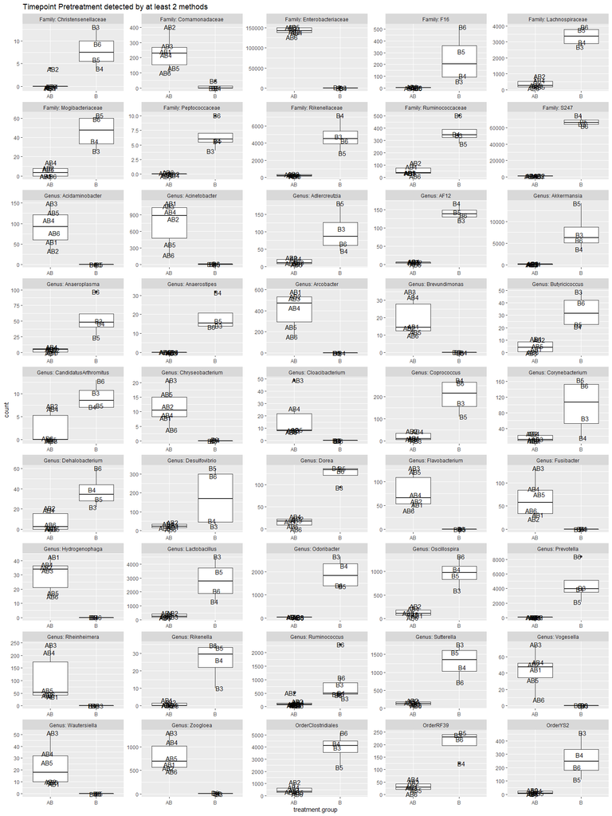

```r
# Pretreatment

#getting the relative aboundances from counts

tsePT_genus_RA <- transformCounts(tsePT_genus,
                              abund_values = "counts",
                               method = "relabundance")
tseT_genus_RA <- transformCounts(tseT_genus,
                              abund_values = "counts",
                              method = "relabundance")
tse_genus_RA <- transformCounts(tse_genus,
                              abund_values = "counts",
                              method = "relabundance")


# Pretreatemnt

plot_dataPT <- data.frame(t(assay(tsePT_genus_RA)))
plot_dataPT$treatment.group <- colData(tsePT_genus_RA)$treatment.group
plot_dataPT$subject.id <- colData(tsePT_genus_RA)$subject.id
plot_dataPT <- plot_dataPT %>% rownames_to_column("sample")
names <- names(plot_dataPT)
first <- names[2]
last <- names[length(names)-2] #jer su zadnja dva reda treatment.group i subject.id
plot_dataPT <- gather(plot_dataPT, genus, count, all_of(first):all_of(last), factor_key=TRUE)
#before match fix points
plot_dataPT$genus <- gsub("[[:punct:]]", "",plot_dataPT$genus)
plot_dataPT <- dplyr::bind_cols(plot_dataPT, summ=summPT$score[match(plot_dataPT$genus, summPT$genus)])
plot_dataPT$genus <- gsub("Family", "Family: ",plot_dataPT$genus)
plot_dataPT$genus <- gsub("Genus", "Genus: ",plot_dataPT$genus)

data = subset(plot_dataPT, plot_dataPT$summ >= 2)


plot <- ggplot(data, aes(x = treatment.group, y= count)) +
              geom_boxplot() +
              geom_text(aes(label = subject.id), size = 4,
                          position =    position_jitter(width = 0.1))  +
              facet_wrap(~genus, scales = "free", ncol = 5) +
              ggtitle("Timepoint Pretreatment detected by at least 2 methods")

plot
```

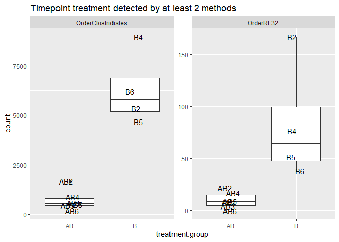

```r
# Treatment

plot_dataT <- data.frame(t(assay(tseT_genus_RA)))
plot_dataT$treatment.group <- colData(tseT_genus_RA)$treatment.group
plot_dataT$subject.id <- colData(tseT_genus_RA)$subject.id
plot_dataT <- plot_dataT %>% rownames_to_column("sample")
names <- names(plot_dataT)
first <- names[2]
last <- names[length(names)-2] #jer su zadnja dva reda treatment.group i subject.id
plot_dataT <- gather(plot_dataT, genus, count, all_of(first):all_of(last), factor_key=TRUE)
#before match fix points
plot_dataT$genus <- gsub("[[:punct:]]", "",plot_dataT$genus)
plot_dataT$genus <- gsub("Family", "Family: ",plot_dataT$genus)
plot_dataT$genus <- gsub("Genus", "Genus: ",plot_dataT$genus)

plot_dataT <- dplyr::bind_cols(plot_dataT, summ=summT$score[match(plot_dataT$genus, summT$genus)])

data = subset(plot_dataT, plot_dataT$summ >= 2)


plot <- ggplot(data, aes(x = treatment.group, y= count)) +
              geom_boxplot() +
              geom_text(aes(label = subject.id), size = 4,
                          position =    position_jitter(width = 0.1))  +
              facet_wrap(~genus, scales = "free", ncol = 5) +
              ggtitle("Timepoint treatment detected by at least 2 methods")

plot
```

COMPARISON OF TIMEPOINTS

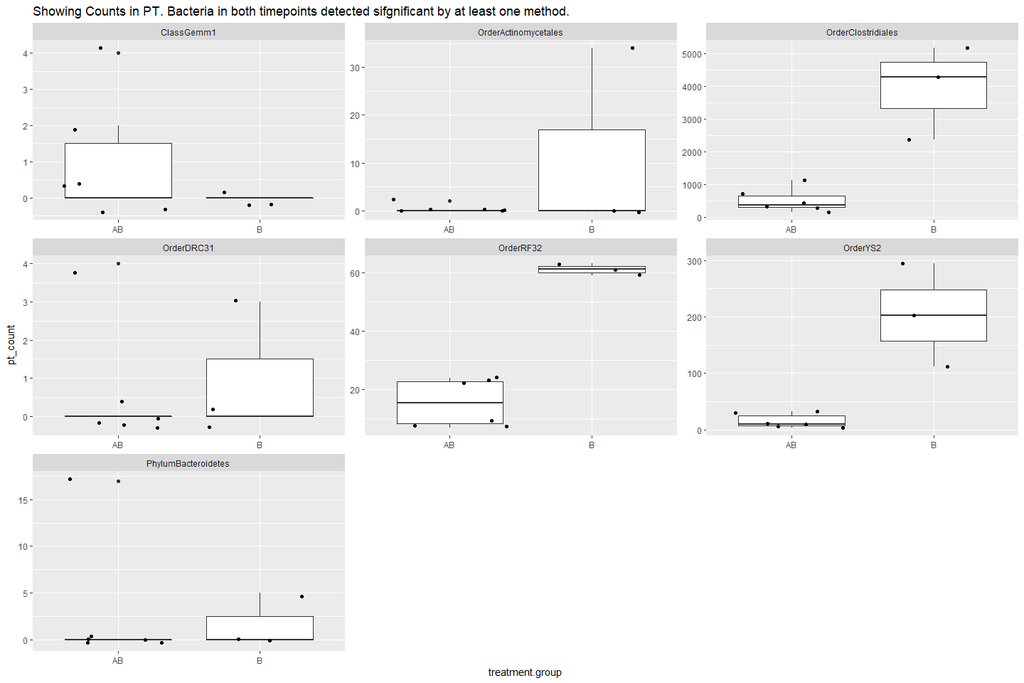

```r
#T1 vs T6

plot_data_PT_vs_T <- full_join(
              dplyr::select(plot_dataPT, subject.id, genus, treatment.group, pt_count = count, summPT = summ),
              dplyr::select(plot_dataT, subject.id, genus, treatment.group, t_count = count, summT = summ),
              by = c("subject.id", "genus", "treatment.group"))


#setting a more loose threshold of q value = 0.1 to see if some bacteria are DA in both timepoints
data = subset(plot_data_PT_vs_T, plot_data_PT_vs_T$summPT >=1 & plot_data_PT_vs_T$summT >=1)


#komentirati ispred plot ako ovo prazan podskup pa daje grešku: (kad nema značajnih u jednom i drugom)
plot <- ggplot(data, aes(x = treatment.group, y= pt_count)) + geom_boxplot() + geom_jitter() + facet_wrap(~genus, scales = "free") + ggtitle("Showing Counts in PT. Bacteria in both timepoints detected sifgnificant by at least one method.")
plot
```